# Importing, Tracking, and Plotting Activity Data

## Importing, Tracking, and Plotting Activity Data

### Loading and Preprocessing the Data

Below, after downloading the file, I read the csv file into a variable  
called “activity_data”. I then used the complete.cases function to remove the NAs  
and only use complete cases for the next question, convert it to a data table  
so I can use dplyr functions, and then change the date column so all the items  
are in date format.

```r
activity_data <- read.csv("activity.csv", colClasses = c("numeric", "character", "numeric"))
activity_data_complete <- activity_data[complete.cases(activity_data),]
library(data.table)
library(dplyr)
activity_dataDT <- as.data.table(activity_data_complete)
activity_dataWithDate <- mutate(activity_dataDT, date = as.POSIXct(date, format = "%Y-%m-%d"))
```

### What is the mean total number of steps per day?

To create a histogram of total number of steps taken each day, I first used  
an aggregate function to get the sum of the total steps taken on each date.  
Then I created a simple histogram with the total steps on the x-axis.

```r
stepsPerDay <- aggregate(steps ~ date, data=activity_dataWithDate, sum)
```

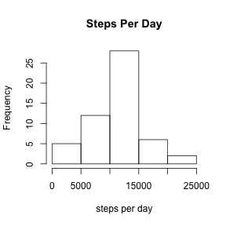

```r
hist(stepsPerDay$steps, main = "Steps Per Day", xlab = "steps per day")
```

To find the mean number of steps, I took the result of my aggregate function  
that summed the steps and used the mean function. I then did the same thing  
with the median function to calculate medianSteps.

```r
meanSteps <- mean(stepsPerDay$steps)
medianSteps <- median(stepsPerDay$steps)
print(meanSteps)
```

```
## [1] 10766.19
```

```r
print(medianSteps)
```

```
## [1] 10765
```

### What is the average daily activity pattern?

For step 1, I first calculated average steps per interval using an aggregate  
function. Then I plotted the average steps calculated against the interval.

```r
stepsPerInterval <- aggregate(steps ~ interval, data=activity_dataWithDate, mean)
```

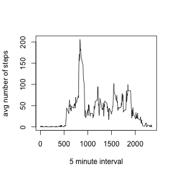

```r
plot(stepsPerInterval$interval, stepsPerInterval$steps, type="l",ylab="avg number of steps", xlab="5 minute interval")
```

To get the 5 minute interval that contained the maximum number of steps, first I calculated  
the max steps using the max function, then converted stepsPerInterval into a data table,  
then filtered the row that contained that max number, storing it in a variable.

```r
maxSteps <- max(stepsPerInterval$steps)
stepsPerIntervalDT <- as.data.table(stepsPerInterval)
intervalMaxFilter <- filter(stepsPerIntervalDT, steps == maxSteps)
intervalMax <- intervalMaxFilter$interval
```

The interval with the maximum number of steps is:

```
## [1] 835
```

### Inputting Missing Values

To calculate the number of missing values, I used the sum and is.na functions  
to count the number of rows with NAs.

```r
numOfMissingRows <- sum(is.na(activity_data))
```

The total number of rows with NAs is:

```r
print(numOfMissingRows)
```

```
## [1] 2304
```

I then took the original data frame and converted it to a data table,  
this time with the missing values, and converted the date column  
from character to date class.

```r
activity_dataDTWNA <- as.data.table(activity_data)
activity_dataWithDateWNA <- mutate(activity_dataDTWNA, date = as.POSIXct(date, format = "%Y-%m-%d"))
```

```r
activity_dataWithDateWNA%>%
        group_by(interval) %>%
        mutate(steps = replace(steps, is.na(steps), mean(steps, na.rm= TRUE)))
```

```
## Source: local data table [17,568 x 3]
## Groups: interval
##
##        steps       date interval
## 1   1.716981 2012-10-01        0
## 2   0.000000 2012-10-02        0
## 3   0.000000 2012-10-03        0
## 4  47.000000 2012-10-04        0
## 5   0.000000 2012-10-05        0
## 6   0.000000 2012-10-06        0
## 7   0.000000 2012-10-07        0
## 8   1.716981 2012-10-08        0
## 9   0.000000 2012-10-09        0
## 10 34.000000 2012-10-10        0
## ..       ...        ...      ...
```

```r
stepsPerDayWNA <- aggregate(steps ~ date, data=activity_dataWithDateWNA, sum)
```

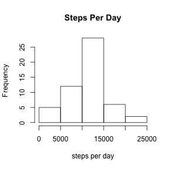

```r
hist(stepsPerDayWNA$steps, main = "Steps Per Day", xlab = "steps per day")
```

```r
meanStepsWNA <- mean(stepsPerDayWNA$steps)
medianStepsWNA <- median(stepsPerDayWNA$steps)
print(meanStepsWNA)
```

```
## [1] 10766.19
```

```r
print(medianStepsWNA)
```

```
## [1] 10765
```

### Are there differences in activity patterns between weekdays and weekends?

To understand this, first I changed the date column in my activity data to reflect days of the  
week, using the weekdays() and mutate() functions. Then I changed the date column into a factor,  
and then added levels to reflect Monday - Friday being weekdays and Saturday and Sunday being weekends.

```r
activity_days_of_week <- mutate(activity_dataWithDateWNA, date=weekdays(date))
activity_days_of_week_factor <- mutate(activity_days_of_week, date=factor(date))
levels(activity_days_of_week_factor$date) <- c("Weekday", "Weekday", "Weekend", "Weekend", "Weekday", "Weekday", "Weekday")
```

I then plotted interval on the x axis but number of steps on the y axis, separated out into two panels,  
one for weekend, and one for weekday. There do seem to be differences in that on weekends, there seem to be  
more steps later in the day than on weekdays.

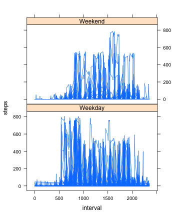

```r
library(lattice)
xyplot(steps ~ interval | date, data=activity_days_of_week_factor, layout = c(1, 2), type = "l")
```